# Bank Term Deposit Classification Problem

## Attributes Information

#### Bank client data:

1 - age (numeric)

2 - job : type of job (categorical: 'admin.','bluecollar','entrepreneur','housemaid','management', 'retired','selfemployed','services','student','technician','unemployed','unknown')

3 - marital : marital status (categorical: 'divorced','married','single','unknown'; note: 'divorced' means divorced or widowed)

4 - education (categorical:'basic.4y','basic.6y','basic.9y','high.school','illiterate','professional.course','u niversity.degree','unknown')

5 - default: has credit in default? (categorical: 'no','yes','unknown')

6 - housing: has housing loan? (categorical: 'no','yes','unknown')

7 - loan: has personal loan? (categorical: 'no','yes','unknown')

#### Related with the last contact of the current campaign:

8 - contact: contact communication type (categorical: 'cellular','telephone')

9 - month: last contact month of year (categorical: 'jan', 'feb', 'mar', ..., 'nov', 'dec')

10 - day_of_week: last contact day of the week (categorical: 'mon','tue','wed','thu','fri')

11 - duration: last contact duration, in seconds (numeric). Important note: this attribute highly affects the output target (e.g., if duration=0 then y='no'). Yet, the duration is not known before a call is performed. Also, after the end of the call y is obviously known. Thus, this input should only be included for benchmark purposes and should be discarded if the intention is to have a realistic predictive model.

#### Other attributes:

12 - campaign: number of contacts performed during this campaign and for this client (numeric, includes last contact)

13 - pdays: number of days that passed by after the client was last contacted from a previous campaign (numeric; 999 means client was not previously contacted)

14 - previous: number of contacts performed before this campaign and for this client (numeric)

15 - poutcome: outcome of the previous marketing campaign (categorical: 'failure','nonexistent','success')

#### Social and economic context attributes

16 - emp.var.rate: employment variation rate - quarterly indicator (numeric)

17 - cons.price.idx: consumer price index - monthly indicator (numeric)

18 - cons.conf.idx: consumer confidence index - monthly indicator (numeric)

19 - euribor3m: euribor 3 month rate - daily indicator (numeric)

20 - nr.employed: number of employees - quarterly indicator (numeric)

### Target Attribute

1. y: if the customer will subscribe to the term-deposit plan or not (0- No, 1-Yes)

#### Importing Libraries

```python
# Importing librries
import pandas as pd
import numpy as np
import os
import plotly.express as px
import matplotlib.pyplot as plt
plt.rc("font", size=14)
import seaborn as sns
sns.set(style="white")
sns.set(style="whitegrid", color_codes=True)
from sklearn import preprocessing
from sklearn.linear_model import LogisticRegression
from sklearn.model_selection import train_test_split
```

```python
# code to ignore warnings
import warnings
warnings.filterwarnings("ignore")
```

```python
pd.set_option('display.max_columns',None)
pd.set_option('display.max_rows',None)
```

```python
pwd
```

```
'C:\\Users\\Dhwani Bhandari\\ML2_end-term'
```

```python
os.chdir('D:\\vu\\terms\\term 9\\Methods and Algorithm in ML- 2\\end-term_hackathon')
```

#### Reading train and test datasets

```python
data= pd.read_csv("bank-additional-full.csv")
```

```python
data.head()
```

|  | customer_no | age | job | marital | education | credit_default | housing | loan | contact | contacted_month | day_of_week | duration | campaign | pdays | previous | poutcome | emp_var_rate | cons_price_idx | cons_conf_idx | euribor3m | nr_employed | y |
| --- | --- | --- | --- | --- | --- | --- | --- | --- | --- | --- | --- | --- | --- | --- | --- | --- | --- | --- | --- | --- | --- | --- |
| 0 | 1 | 56 | housemaid | married | basic.4y | no | no | no | telephone | may | mon | 261 | 1 | 999 | 0 | nonexistent | 1.1 | 93.994 | -36.4 | 4.857 | 5191.0 | no |
| 1 | 2 | 57 | services | married | high.school | unknown | no | no | telephone | may | mon | 149 | 1 | 999 | 0 | nonexistent | 1.1 | 93.994 | -36.4 | 4.857 | 5191.0 | no |
| 2 | 3 | 37 | services | married | high.school | no | yes | no | telephone | may | mon | 226 | 1 | 999 | 0 | nonexistent | 1.1 | 93.994 | -36.4 | 4.857 | 5191.0 | no |
| 3 | 4 | 40 | admin. | married | basic.6y | no | no | no | telephone | may | mon | 151 | 1 | 999 | 0 | nonexistent | 1.1 | 93.994 | -36.4 | 4.857 | 5191.0 | no |
| 4 | 5 | 56 | services | married | high.school | no | no | yes | telephone | may | mon | 307 | 1 | 999 | 0 | nonexistent | 1.1 | 93.994 | -36.4 | 4.857 | 5191.0 | no |

```python
data.shape
```

```
(41188, 22)
```

```python
data.info()
```

```
<class 'pandas.core.frame.DataFrame'>
RangeIndex: 41188 entries, 0 to 41187
Data columns (total 22 columns):
 #   Column           Non-Null Count  Dtype
---  ------           --------------  -----
 0   customer_no      41188 non-null  int64
 1   age              41188 non-null  int64
 2   job              41188 non-null  object
 3   marital          41188 non-null  object
 4   education        41188 non-null  object
 5   credit_default   41188 non-null  object
 6   housing          41188 non-null  object
 7   loan             41188 non-null  object
 8   contact          41188 non-null  object
 9   contacted_month  41188 non-null  object
 10  day_of_week      41188 non-null  object
 11  duration         41188 non-null  int64
 12  campaign         41188 non-null  int64
 13  pdays            41188 non-null  int64
 14  previous         41188 non-null  int64
 15  poutcome         41188 non-null  object
 16  emp_var_rate     41188 non-null  float64
 17  cons_price_idx   41188 non-null  float64
 18  cons_conf_idx    41188 non-null  float64
 19  euribor3m        41188 non-null  float64
 20  nr_employed      41188 non-null  float64
 21  y                41188 non-null  object
dtypes: float64(5), int64(6), object(11)
memory usage: 6.9+ MB
```

#### There are no missing values in the data.

```python
# Transaction number is unique and works as a id for each customer.
data_label= data['customer_no']

# Select all columns except "customer_number"
data.drop(['customer_no'], axis=1, inplace=True)
data.head(2)
```

|  | age | job | marital | education | credit_default | housing | loan | contact | contacted_month | day_of_week | duration | campaign | pdays | previous | poutcome | emp_var_rate | cons_price_idx | cons_conf_idx | euribor3m | nr_employed | y |
| --- | --- | --- | --- | --- | --- | --- | --- | --- | --- | --- | --- | --- | --- | --- | --- | --- | --- | --- | --- | --- | --- |
| 0 | 56 | housemaid | married | basic.4y | no | no | no | telephone | may | mon | 261 | 1 | 999 | 0 | nonexistent | 1.1 | 93.994 | -36.4 | 4.857 | 5191.0 | no |
| 1 | 57 | services | married | high.school | unknown | no | no | telephone | may | mon | 149 | 1 | 999 | 0 | nonexistent | 1.1 | 93.994 | -36.4 | 4.857 | 5191.0 | no |

#### Checking the count of unique values of a ttribute

```python
data.nunique()
```

```
age                  78
job                  12
marital               4
education             9
credit_default        3
housing               3
loan                  3
contact               2
contacted_month      10
day_of_week           5
duration           1544
campaign             42
pdays                27
previous              8
poutcome              3
emp_var_rate         10
cons_price_idx       26
cons_conf_idx        26
euribor3m           316
nr_employed          11
y                     2
dtype: int64
```

```python
data.describe()
```

|  | age | duration | campaign | pdays | previous | emp_var_rate | cons_price_idx | cons_conf_idx | euribor3m | nr_employed |
| --- | --- | --- | --- | --- | --- | --- | --- | --- | --- | --- |
| count | 41188.00000 | 41188.000000 | 41188.000000 | 41188.000000 | 41188.000000 | 41188.000000 | 41188.000000 | 41188.000000 | 41188.000000 | 41188.000000 |
| mean | 40.02406 | 258.285010 | 2.567593 | 962.475454 | 0.172963 | 0.081886 | 93.575664 | -40.502600 | 3.621291 | 5167.035911 |
| std | 10.42125 | 259.279249 | 2.770014 | 186.910907 | 0.494901 | 1.570960 | 0.578840 | 4.628198 | 1.734447 | 72.251528 |
| min | 17.00000 | 0.000000 | 1.000000 | 0.000000 | 0.000000 | -3.400000 | 92.201000 | -50.800000 | 0.634000 | 4963.600000 |
| 25% | 32.00000 | 102.000000 | 1.000000 | 999.000000 | 0.000000 | -1.800000 | 93.075000 | -42.700000 | 1.344000 | 5099.100000 |
| 50% | 38.00000 | 180.000000 | 2.000000 | 999.000000 | 0.000000 | 1.100000 | 93.749000 | -41.800000 | 4.857000 | 5191.000000 |
| 75% | 47.00000 | 319.000000 | 3.000000 | 999.000000 | 0.000000 | 1.400000 | 93.994000 | -36.400000 | 4.961000 | 5228.100000 |
| max | 98.00000 | 4918.000000 | 56.000000 | 999.000000 | 7.000000 | 1.400000 | 94.767000 | -26.900000 | 5.045000 | 5228.100000 |

#### Corrplot to check the correlation between the attributes

```
                     age  duration  campaign     pdays  previous  \
age             1.000000 -0.000866  0.004594 -0.034369  0.024365
duration       -0.000866  1.000000 -0.071699 -0.047577  0.020640
campaign        0.004594 -0.071699  1.000000  0.052584 -0.079141
pdays          -0.034369 -0.047577  0.052584  1.000000 -0.587514
previous        0.024365  0.020640 -0.079141 -0.587514  1.000000
emp_var_rate   -0.000371 -0.027968  0.150754  0.271004 -0.420489
cons_price_idx  0.000857  0.005312  0.127836  0.078889 -0.203130
cons_conf_idx   0.129372 -0.008173 -0.013733 -0.091342 -0.050936
euribor3m       0.010767 -0.032897  0.135133  0.296899 -0.454494
nr_employed    -0.017725 -0.044703  0.144095  0.372605 -0.501333

                emp_var_rate  cons_price_idx  cons_conf_idx  euribor3m  \
age                -0.000371        0.000857       0.129372   0.010767
duration           -0.027968        0.005312      -0.008173  -0.032897
campaign            0.150754        0.127836      -0.013733   0.135133
pdays               0.271004        0.078889      -0.091342   0.296899
previous           -0.420489       -0.203130      -0.050936  -0.454494
emp_var_rate        1.000000        0.775334       0.196041   0.972245
cons_price_idx      0.775334        1.000000       0.058986   0.688230
cons_conf_idx       0.196041        0.058986       1.000000   0.277686
euribor3m           0.972245        0.688230       0.277686   1.000000
nr_employed         0.906970        0.522034       0.100513   0.945154

                nr_employed
age               -0.017725
duration          -0.044703
campaign           0.144095
pdays              0.372605
previous          -0.501333
emp_var_rate       0.906970
cons_price_idx     0.522034
cons_conf_idx      0.100513
euribor3m          0.945154
nr_employed        1.000000
```

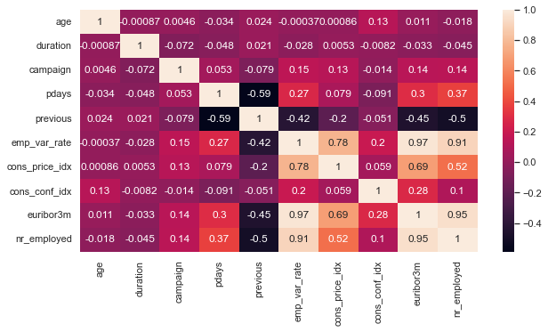

```python
print(data.corr())

# plotting correlation heatmap
plt.figure(figsize=(10,5), facecolor='white')
dataplot = sns.heatmap(data.corr(), annot=True)

# displaying heatmap
plt.show()
```

## EDA

- Find Missing Values
- Explore the Categorical Features
- Find Categorical Feature Distribution
- Relationship between Categorical Features and Label
- Explore the Numerical Features
- Find Numerical Feature Distribution
- Relation between numerical Features and Labels
- Check the Data set is balanced or not based on target values in classification

```python
df=data
```

```python
# find missing values
features_na = [features for features in df.columns if df[features].isnull().sum() > 0]
for feature in features_na:
    print(feature, np.round(df[feature].isnull().mean(), 4),  ' % missing values')
else:
    print("Null")
```

```
Null
```

#### No missing value found

```python
# find features with one value
for column in df.columns:
    print(column,df[column].nunique())
```

```
age 78
job 12
marital 4
education 9
credit_default 3
housing 3
loan 3
contact 2
contacted_month 10
day_of_week 5
duration 1544
campaign 42
pdays 27
previous 8
poutcome 3
emp_var_rate 10
cons_price_idx 26
cons_conf_idx 26
euribor3m 316
nr_employed 11
y 2
```

### Categorical features

```python
# explore categorical features
categorical_features=[feature for feature in df.columns if ((df[feature].dtypes=='O') & (feature not in ['y']))]
categorical_features
```

```
['job',
 'marital',
 'education',
 'credit_default',
 'housing',
 'loan',
 'contact',
 'contacted_month',
 'day_of_week',
 'poutcome']
```

### Job

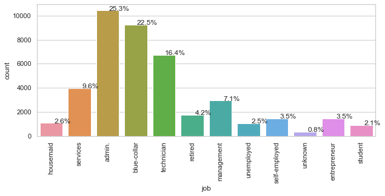

```python
plt.figure(figsize=(10,4))
ax=sns.countplot(x='job',data=df)
plt.xticks(rotation='vertical')

for p in ax.patches:
    percentage = '{:.1f}%'.format(100 * p.get_height()/len(df))
    x = p.get_x() + p.get_width()
    y = p.get_height()
    ax.annotate(percentage, (x, y),ha='center')
plt.show()
```

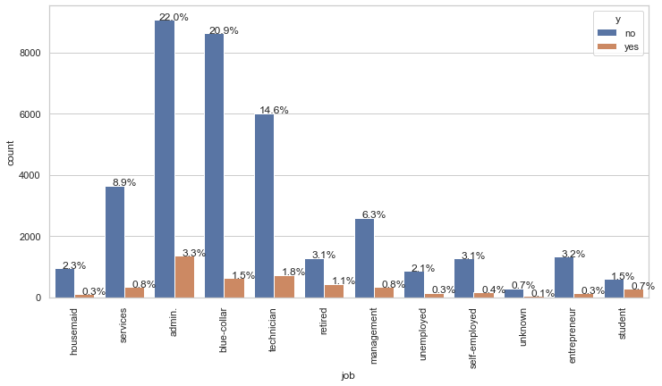

```python
plt.figure(figsize=(12,6))
ax=sns.countplot(data=df,x='job',hue='y')
for p in ax.patches:
    percentage = '{:.1f}%'.format(100 * p.get_height()/len(df))
    x = p.get_x() + p.get_width()
    y = p.get_height()
    ax.annotate(percentage, (x, y),ha='center')
plt.xticks(rotation='vertical')
plt.show()
```

```python
# We need to reduce the nos of categories in 'job'
df['job'].unique()
```

```
array(['housemaid', 'services', 'admin.', 'blue-collar', 'technician',
       'retired', 'management', 'unemployed', 'self-employed', 'unknown',
       'entrepreneur', 'student'], dtype=object)
```

```python
def job_new(job):
    if job in ['self-employed','housemaid','entrepreneur']:
        return 'self_employed'
    elif job in ['unknown','unemployed','student']:
        return 'unemployed'
    elif job in ['blue-collar','services']:
        return 'blue_collar'
    else:
        return job
```

```python
df['job_type']=df['job'].map(job_new)
```

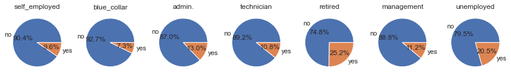

```python
fig,ax=plt.subplots(1,df['job_type'].nunique(),figsize=(15,20))
for i,col in enumerate(df['job_type'].unique()):
    ax[i].pie(x=df[df['job_type']==col]['y'].value_counts(),
              labels=df[df['job_type']==col]['y'].value_counts().index,autopct='%1.1f%%')
    ax[i].set_title(col)
```

**Retired and unemployed people are more likely to be converted compared to blue-collar and self-employed people.**

**But lesser nos of retired people have been contacted historically.**

### Marital

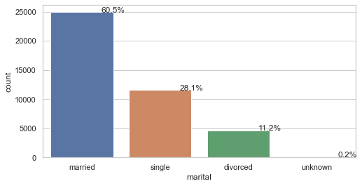

```python
plt.figure(figsize=(8,4))
ax=sns.countplot(x='marital',data=df)
for p in ax.patches:
    percentage = '{:.1f}%'.format(100 * p.get_height()/len(df))
    x = p.get_x() + p.get_width()
    y = p.get_height()
    ax.annotate(percentage, (x, y),ha='center')
plt.show()
```

**Most of the customers are married.**

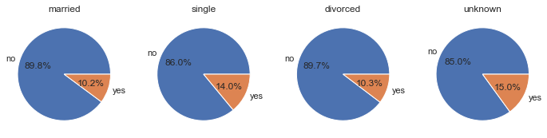

```python
fig,ax=plt.subplots(1,df['marital'].nunique(),figsize=(12,8))
for i,col in enumerate(df['marital'].unique()):
    ax[i].pie(x=df[df['marital']==col]['y'].value_counts(),
              labels=df[df['marital']==col]['y'].value_counts().index,autopct='%1.1f%%')
    ax[i].set_title(col)
```

**Single people are a little more likely to be converted than married and divorced people.**

### Education

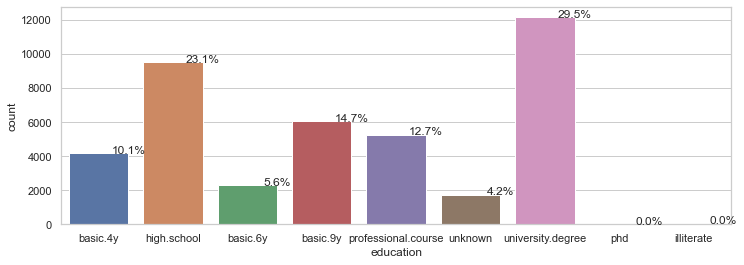

```python
plt.figure(figsize=(12,4))
ax=sns.countplot(x='education',data=df)
for p in ax.patches:
    percentage = '{:.1f}%'.format(100 * p.get_height()/len(df))
    x = p.get_x() + p.get_width()
    y = p.get_height()
    ax.annotate(percentage, (x, y),ha='center')
```

**50% of the customers have a university degree or have atleast gone to a high school**

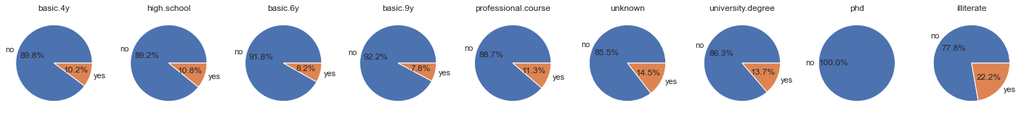

```python
fig,ax=plt.subplots(1,df['education'].nunique(),figsize=(25,35))
for i,col in enumerate(df['education'].unique()):
    ax[i].pie(x=df[df['education']==col]['y'].value_counts(),
              labels=df[df['education']==col]['y'].value_counts().index,autopct='%1.1f%%')
    ax[i].set_title(col)
```

**Illiterate people show a higher conversion rate.**

**People having a phd show a 0 conversion rate.**

### Credit_default

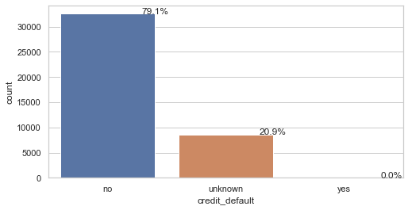

```python
plt.figure(figsize=(8,4))
ax=sns.countplot(x='credit_default',data=df)
for p in ax.patches:
    percentage = '{:.1f}%'.format(100 * p.get_height()/len(df))
    x = p.get_x() + p.get_width()
    y = p.get_height()
    ax.annotate(percentage, (x, y),ha='center')
```

**majority of the customers haven't defaulted.**

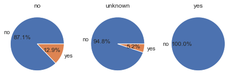

```python
fig,ax=plt.subplots(1,df['credit_default'].nunique(),figsize=(8,6))
for i,col in enumerate(df['credit_default'].unique()):
    ax[i].pie(x=df[df['credit_default']==col]['y'].value_counts(),
              labels=df[df['credit_default']==col]['y'].value_counts().index,autopct='%1.1f%%')
    ax[i].set_title(col)
```

**People who haven't defaulted are only most likely to subscribe.**

### Housing

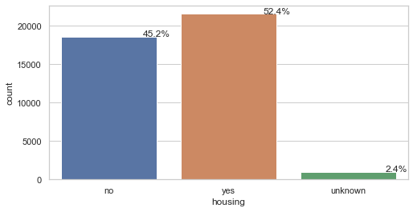

```python
plt.figure(figsize=(8,4))
ax=sns.countplot(x='housing',data=df)
for p in ax.patches:
    percentage = '{:.1f}%'.format(100 * p.get_height()/len(df))
    x = p.get_x() + p.get_width()
    y = p.get_height()
    ax.annotate(percentage, (x, y),ha='center')
```

**Almost equal split of whether the customers have taken home loan or not.**

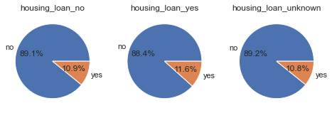

```python
fig,ax=plt.subplots(1,df['housing'].nunique(),figsize=(8,6))
for i,col in enumerate(df['housing'].unique()):
    ax[i].pie(x=df[df['housing']==col]['y'].value_counts(),
              labels=df[df['housing']==col]['y'].value_counts().index,autopct='%1.1f%%')
    ax[i].set_title('housing_loan_'+col)
```

### Loan

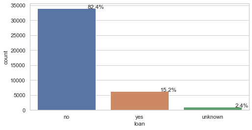

```python
plt.figure(figsize=(8,4))
ax=sns.countplot(x='loan',data=df)
for p in ax.patches:
    percentage = '{:.1f}%'.format(100 * p.get_height()/len(df))
    x = p.get_x() + p.get_width()
    y = p.get_height()
    ax.annotate(percentage, (x, y),ha='center')
```

**Majority customers haven't taken a personal loan.**

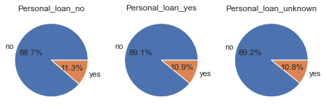

```python
fig,ax=plt.subplots(1,df['loan'].nunique(),figsize=(8,6))
for i,col in enumerate(df['loan'].unique()):
    ax[i].pie(x=df[df['loan']==col]['y'].value_counts(),
              labels=df[df['loan']==col]['y'].value_counts().index,autopct='%1.1f%%')
    ax[i].set_title('Personal_loan_'+col)
```

### Contact

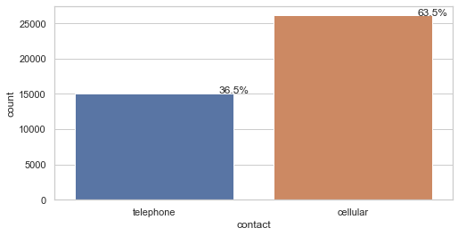

```python
plt.figure(figsize=(8,4))
ax=sns.countplot(x='contact',data=df)
for p in ax.patches:
    percentage = '{:.1f}%'.format(100 * p.get_height()/len(df))
    x = p.get_x() + p.get_width()
    y = p.get_height()
    ax.annotate(percentage, (x, y),ha='center')
```

**Most of the customers have been contacted on their cell phones.**

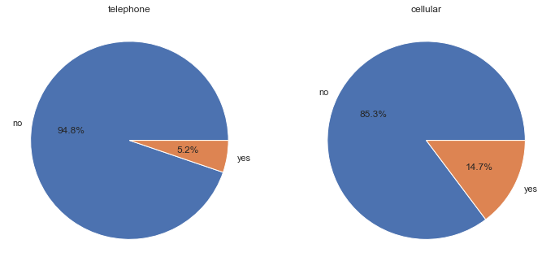

```python
fig,ax=plt.subplots(1,df['contact'].nunique(),figsize=(12,10))
for i,col in enumerate(df['contact'].unique()):
    ax[i].pie(x=df[df['contact']==col]['y'].value_counts(),
              labels=df[df['contact']==col]['y'].value_counts().index,autopct='%1.1f%%')
    ax[i].set_title(col)
```

**People called on cell have better chances of conversion.**

### Contacted_month

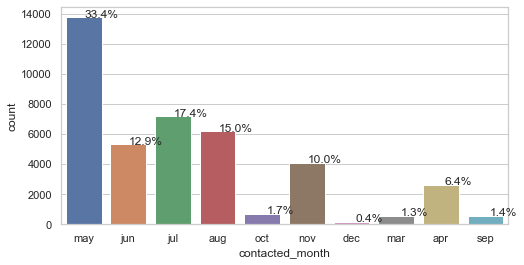

```python
plt.figure(figsize=(8,4))
# months=['jan','feb','mar','apr','may','jun','jul','aug','sep','oct','nov','dec']
ax=sns.countplot(x='contacted_month',data=df)
for p in ax.patches:
    percentage = '{:.1f}%'.format(100 * p.get_height()/len(df))
    x = p.get_x() + p.get_width()
    y = p.get_height()
    ax.annotate(percentage, (x, y),ha='center')
```

**Most of the people were called during May-Aug during the current campaign.**

**May being the month with the highest number of contacts.**

**No contact in the months of jan, feb**

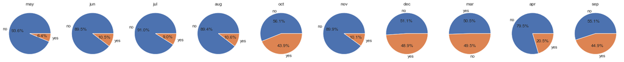

```python
fig,ax=plt.subplots(1,df['contacted_month'].nunique(),figsize=(30,20))
for i,col in enumerate(df['contacted_month'].unique()):
    ax[i].pie(x=df[df['contacted_month']==col]['y'].value_counts(),
              labels=df[df['contacted_month']==col]['y'].value_counts().index,autopct='%1.1f%%')
    ax[i].set_title(col)
```

**September, October, December and March have recorded the best conversion rates of around 45% and more.**

### day_of_week

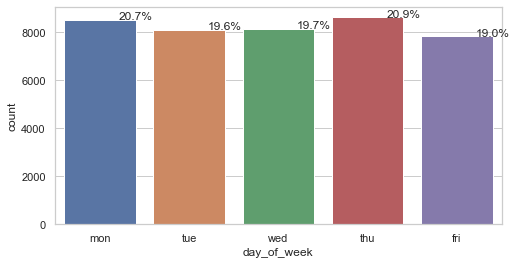

```python
plt.figure(figsize=(8,4))
# days=['mon','tue','wed','thu','fri']
ax=sns.countplot(x='day_of_week',data=df)
for p in ax.patches:
    percentage = '{:.1f}%'.format(100 * p.get_height()/len(df))
    x = p.get_x() + p.get_width()
    y = p.get_height()
    ax.annotate(percentage, (x, y),ha='center')
```

**customers have been contacted almost equally on all the days**

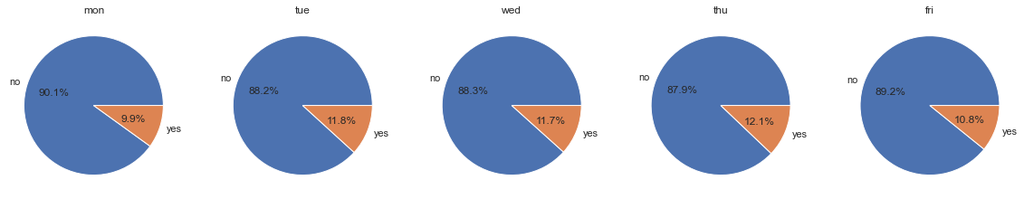

```python
fig,ax=plt.subplots(1,df['day_of_week'].nunique(),figsize=(20,15))
for i,col in enumerate(df['day_of_week'].unique()):
    ax[i].pie(x=df[df['day_of_week']==col]['y'].value_counts(),
              labels=df[df['day_of_week']==col]['y'].value_counts().index,autopct='%1.1f%%')
    ax[i].set_title(col)
```

### poutcome (Previous campaign outcome)

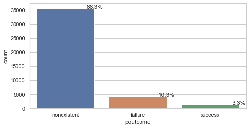

```python
plt.figure(figsize=(8,4))
ax=sns.countplot(x='poutcome',data=df)
for p in ax.patches:
    percentage = '{:.1f}%'.format(100 * p.get_height()/len(df))
    x = p.get_x() + p.get_width()
    y = p.get_height()
    ax.annotate(percentage, (x, y),ha='center')
```

**Most of the Previous campaign outcomes are unknown, so better data collection is needed.**

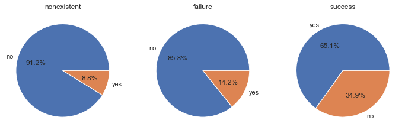

```python
fig,ax=plt.subplots(1,df['poutcome'].nunique(),figsize=(12,10))
for i,col in enumerate(df['poutcome'].unique()):
    ax[i].pie(x=df[df['poutcome']==col]['y'].value_counts(),
              labels=df[df['poutcome']==col]['y'].value_counts().index,autopct='%1.1f%%')
    ax[i].set_title(col)
```

**If in previous campaign, they subscribed, it is highly probable that they will subscribe in current campaign as well.**

**Also, cause of unknown outcome need to be explored to derive more insights.**

## Numerical Features

```python
# find numerical features
numerical_features=[feature for feature in df.columns if ((df[feature].dtypes!='O') & (feature not in ['y']))]

print("Numerical feature Count {}".format(len(numerical_features)))
print("Numerical feature Names {}".format((numerical_features)))
```

```
Numerical feature Count 10
Numerical feature Names ['age', 'duration', 'campaign', 'pdays', 'previous', 'emp_var_rate', 'cons_price_idx', 'cons_conf_idx', 'euribor3m', 'nr_employed']
```

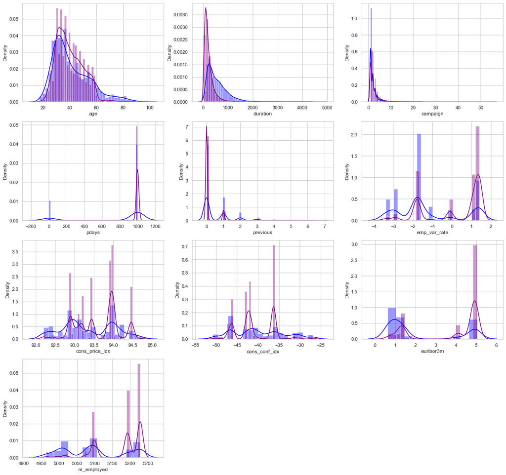

```python
# Distribution of numerical features

plt.figure(figsize=(20,60), facecolor='white')
plotnumber =1
for feature in numerical_features:
    ax = plt.subplot(12,3,plotnumber)
    # sns.distplot(df[continuous_feature], color='y')
    sns.distplot(df[df['y']=='yes'][feature],color='blue',ax=ax,label='yes')
    sns.distplot(df[df['y']=='no'][feature],color='purple',ax=ax,label='no')
    plt.xlabel(feature)
    plotnumber+=1
plt.show()
```

### Age

- In case of 'Not-Subscribed', 70 yrs+ is considered outlier, while for 'Subscribed' it is not.
- So the average age for 'Subscribed' group is higher.

### Duration

- So, we see that longer calls during last contact are more likely to get converted, indicating they have taken time to understand about the product from the calling agents.

### Campaign

- 80% of those subscribed have been contacted between 0-3 times during this campaign.
- So, it makes sense not to contact people beyond at most 5 times during a campaign.

### pdays

- For most of the customers, they are being contacted for the first time in this campaign. (since 999 indicates they haven't been contatced previously, almost 90%)

### previous

- So, most of the customers were contacted for the first time during this campaign.
- Hence 0 contacts before this campaign.
- If contacted between 2-3 times they're most likely to get converted

### emp_var_rate

- if this is less the subscription rate will be more

### cons_price_idx

- change in cpi measures changes in price overtime
- Basically if this would be more people would be earning more money

### cons_conf_idx

- subscription rate remains mostly low throughout

### euribor3m

- the interest rate of banks for 3 months
- So how are people subscribing based on interest rates (Highest around 1 )

### nr_employed

- subscription rate remains low throughout

#### Relationship of Campaign success with Age

```python
# Discretize the age Column to age group
from sklearn.preprocessing import KBinsDiscretizer
disc=KBinsDiscretizer(n_bins=5,strategy='quantile',encode='ordinal')
```

```python
disc.fit(df[['age']])
```

```
KBinsDiscretizer(encode='ordinal')
```

```python
df['age_rank']=disc.transform(df[['age']])
```

```python
disc.bin_edges_
```

```
array([array([17., 31., 35., 41., 49., 98.])], dtype=object)
```

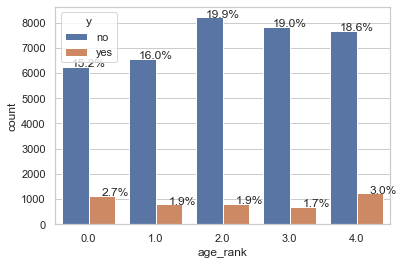

```python
ax=sns.countplot(data=df,x='age_rank',hue='y')
for p in ax.patches:
    percentage = '{:.1f}%'.format(100 * p.get_height()/len(df))
    x = p.get_x() + p.get_width()
    y = p.get_height()
    ax.annotate(percentage, (x, y),ha='center')
```

**So, we see that the conversion is better for youngest and oldest age_groups.**

**Hence we can target these two demographics, rather than the middle age groups**

```python
def age_group(age):
    if age<31:
        return 'young'
    elif age<51:
        return 'middle'
    else:
        return 'senior'
```

```python
df['age_group']=df['age'].map(age_group)
```

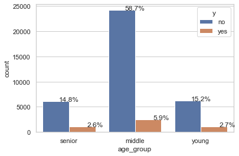

```python
ax=sns.countplot(data=df,x='age_group',hue='y')
for p in ax.patches:
    percentage = '{:.1f}%'.format(100 * p.get_height()/len(df))
    x = p.get_x() + p.get_width()
    y = p.get_height()
    ax.annotate(percentage, (x, y),ha='center')
```

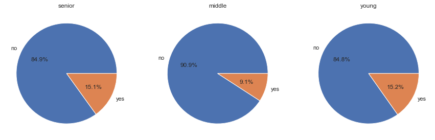

```python
fig,ax=plt.subplots(1,df['age_group'].nunique(),figsize=(15,20))
for i,col in enumerate(df['age_group'].unique()):
    ax[i].pie(x=df[df['age_group']==col]['y'].value_counts(),
              labels=df[df['age_group']==col]['y'].value_counts().index,autopct='%1.1f%%')
    ax[i].set_title(col)
```

**Senior(older than 51) and young(younger than 31) age-groups are far more likely to respond than middle age-group people.**

**But they are called the least, this could be the reason why run-rate has been low.**

## Relationship of Campaign success with Duration of last call

```python
# transform duration into minutes
df['duration']=df['duration']/60
```

```python
disc_dur=KBinsDiscretizer(n_bins=5,strategy='quantile',encode='ordinal')
disc_dur.fit(df[['duration']])
df['duration_rank']=disc_dur.transform(df[['duration']])
```

```python
disc_dur.bin_edges_
```

```
array([array([ 0.        ,  1.48333333,  2.43333333,  3.7       ,  6.13333333,
              81.96666667])                                                   ],
      dtype=object)
```

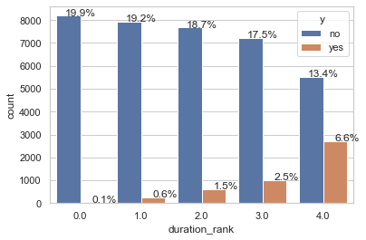

```python
ax=sns.countplot(data=df,x='duration_rank',hue='y')
for p in ax.patches:
    percentage = '{:.1f}%'.format(100 * p.get_height()/len(df))
    x = p.get_x() + p.get_width()
    y = p.get_height()
    ax.annotate(percentage, (x, y),ha='center')
```

```python
def call_time(time):
    if time<=1:
        return '<1min'
    elif time<=3:
        return '1-3min'
    elif time<=10:
        return '3-10min'
    else:
        return '>10 min'
```

```python
df['call_dur']=df['duration'].map(call_time)
```

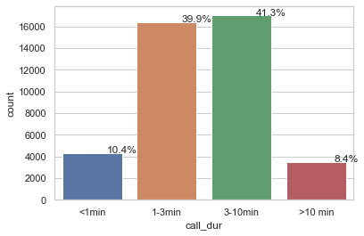

```python
ax=sns.countplot(data=df,x='call_dur',order=['<1min','1-3min','3-10min','>10 min'])
for p in ax.patches:
    percentage = '{:.1f}%'.format(100 * p.get_height()/len(df))
    x = p.get_x() + p.get_width()
    y = p.get_height()
    ax.annotate(percentage, (x, y),ha='center')
```

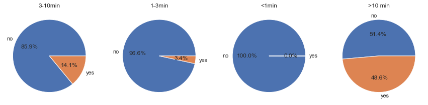

```python
fig,ax=plt.subplots(1,df['call_dur'].nunique(),figsize=(15,10))
for i,col in enumerate(df['call_dur'].unique()):
    ax[i].pie(x=df[df['call_dur']==col]['y'].value_counts(),
              labels=df[df['call_dur']==col]['y'].value_counts().index,autopct='%1.1f%%')
    ax[i].set_title(col)
```

**So, as the duration of last contact increases beyond 3 mins, conversion increases to 15% and above 10 mins it is almost 50%.**

## Relationship of Campaign success with Nos of contacts during this campaign

```
(0.0, 25.0)
```

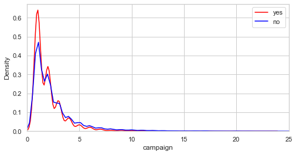

```python
fig,ax=plt.subplots(figsize=(8,4))
sns.distplot(df[df['y']=='yes']['campaign'],color='red',hist=False,ax=ax,label='yes')
sns.distplot(df[df['y']=='no']['campaign'],color='blue',hist=False,ax=ax,label='no')
ax.legend()
ax.set_xlim(0,25)
```

## Relationship of Campaign success with no of days since last contact

```python
df['pdays'].describe().T
```

```
count    41188.000000
mean       962.475454
std        186.910907
min          0.000000
25%        999.000000
50%        999.000000
75%        999.000000
max        999.000000
Name: pdays, dtype: float64
```

We can divide into customers who are newly contacted (pdays=999) and customers who have been previously contacted (!=999)

```python
df['new_contact']=df['pdays'].apply(lambda x:'new_cust' if x==999 else 'old_cust')
```

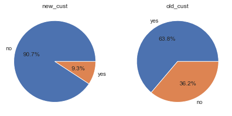

```python
fig,ax=plt.subplots(1,df['new_contact'].nunique(),figsize=(8,6))
for i,col in enumerate(df['new_contact'].unique()):
    ax[i].pie(x=df[df['new_contact']==col]['y'].value_counts(),
              labels=df[df['new_contact']==col]['y'].value_counts().index,autopct='%1.1f%%')
    ax[i].set_title(col)
```

**So, old customers (i.e., those previously contacted are more likely to subscribe than those contacted for first time).**

#### Target Attribute

```python
df.y.value_counts(normalize=True)
```

```
no     0.887346
yes    0.112654
Name: y, dtype: float64
```

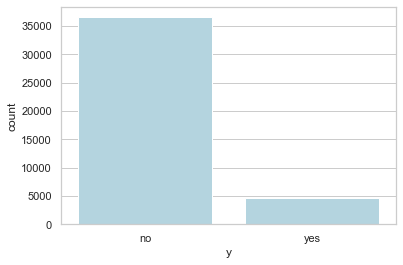

```python
sns.countplot(x='y',data=df, color= "lightblue")
plt.show()
```

**There is a class imbalance in this dataset.**

# Train-Test split

```python
from sklearn.model_selection import train_test_split
```

```python
df.columns
```

```
Index(['age', 'job', 'marital', 'education', 'credit_default', 'housing',
       'loan', 'contact', 'contacted_month', 'day_of_week', 'duration',
       'campaign', 'pdays', 'previous', 'poutcome', 'emp_var_rate',
       'cons_price_idx', 'cons_conf_idx', 'euribor3m', 'nr_employed', 'y',
       'job_type', 'age_rank', 'age_group', 'duration_rank', 'call_dur',
       'new_contact'],
      dtype='object')
```

```python
feat=['marital', 'education', 'credit_default', 'housing',
       'loan', 'contact', 'contacted_month', 'day_of_week',
       'campaign',  'previous', 'poutcome', 'emp_var_rate',
       'cons_price_idx', 'cons_conf_idx', 'euribor3m', 'nr_employed',
       'age_group', 'job_type','new_contact']
```

```python
X=df[feat]
y=df['y'].apply(lambda x: 1 if x=='yes' else 0)
```

```python
X_train, X_test, y_train, y_test = train_test_split(X, y, test_size=0.25, random_state=42)
```

```python
print(X_train.shape)
print(X_test.shape)
print(y_train.shape)
print(y_test.shape)
```

```
(30891, 19)
(10297, 19)
(30891,)
(10297,)
```

```python
X_train=pd.get_dummies(X_train,columns=['job_type', 'marital', 'education','credit_default','housing', 'loan',
                                       'contact', 'contacted_month','poutcome','age_group',
                                        'day_of_week','new_contact'],drop_first=False)
```

```python
X_train.sample(2)
```

|  | campaign | previous | emp_var_rate | cons_price_idx | cons_conf_idx | euribor3m | nr_employed | job_type_admin. | job_type_blue_collar | job_type_management | job_type_retired | job_type_self_employed | job_type_technician | job_type_unemployed | marital_divorced | marital_married | marital_single | marital_unknown | education_basic.4y | education_basic.6y | education_basic.9y | education_high.school | education_illiterate | education_phd | education_professional.course | education_university.degree | education_unknown | credit_default_no | credit_default_unknown | … |
| --- | --- | --- | --- | --- | --- | --- | --- | --- | --- | --- | --- | --- | --- | --- | --- | --- | --- | --- | --- | --- | --- | --- | --- | --- | --- | --- | --- | --- | --- | --- |
| 15749 | 1 | 0 | 1.4 | 93.918 | -42.7 | 4.960 | 5228.1 | 1 | 0 | 0 | 0 | 0 | 0 | 0 | 0 | 1 | 0 | 0 | 0 | 0 | 0 | 0 | 0 | 0 | 0 | 1 | 0 | 0 | 1 | … |
| 419 | 1 | 0 | 1.1 | 93.994 | -36.4 | 4.857 | 5191.0 | 0 | 0 | 0 | 0 | 0 | 1 | 0 | 0 | 0 | 1 | 0 | 0 | 0 | 0 | 0 | 0 | 0 | 0 | 1 | 0 | 1 | 0 | … |

```python
X_test=pd.get_dummies(X_test,columns=['job_type', 'marital', 'education','credit_default','housing', 'loan',
                                       'contact', 'contacted_month','poutcome','age_group',
                                        'day_of_week', 'new_contact'],drop_first=False)
```

```python
X_test.sample(2)
```

|  | campaign | previous | emp_var_rate | cons_price_idx | cons_conf_idx | euribor3m | nr_employed | job_type_admin. | job_type_blue_collar | job_type_management | job_type_retired | job_type_self_employed | job_type_technician | job_type_unemployed | marital_divorced | marital_married | marital_single | marital_unknown | education_basic.4y | education_basic.6y | education_basic.9y | education_high.school | education_illiterate | education_phd | education_professional.course | education_university.degree | education_unknown | credit_default_no | credit_default_unknown | … |
| --- | --- | --- | --- | --- | --- | --- | --- | --- | --- | --- | --- | --- | --- | --- | --- | --- | --- | --- | --- | --- | --- | --- | --- | --- | --- | --- | --- | --- | --- | --- |
| 13754 | 1 | 0 | 1.4 | 93.918 | -42.7 | 4.963 | 5228.1 | 0 | 1 | 0 | 0 | 0 | 0 | 0 | 0 | 0 | 1 | 0 | 0 | 1 | 0 | 0 | 0 | 0 | 0 | 0 | 0 | 1 | 0 | … |
| 13552 | 1 | 0 | 1.4 | 93.918 | -42.7 | 4.963 | 5228.1 | 0 | 0 | 0 | 0 | 0 | 1 | 0 | 0 | 1 | 0 | 0 | 0 | 0 | 0 | 0 | 0 | 0 | 0 | 1 | 0 | 1 | 0 | … |

```python
print(X_train.shape)
print(X_test.shape)
```

```
(30891, 61)
(10297, 61)
```

```python
#importing various models
from sklearn.linear_model import LogisticRegression
from sklearn.ensemble import RandomForestClassifier,AdaBoostClassifier
from xgboost import XGBClassifier
# from imblearn.under_sampling import RandomUnderSampler
from imblearn.ensemble import BalancedRandomForestClassifier,BalancedBaggingClassifier,RUSBoostClassifier, EasyEnsembleClassifier
```

## Initializing with a Random Forest Model

```python
rf=RandomForestClassifier(n_jobs=-1,oob_score=True)
```

```python
rf.fit(X_train,y_train)
```

```
RandomForestClassifier(n_jobs=-1, oob_score=True)
```

```python
rf.oob_score_
```

```
0.8873458288821987
```

```python
rf.feature_importances_
```

```
array([1.06859104e-01, 1.59067160e-02, 2.06374998e-02, 2.07695948e-02,
       2.64774552e-02, 1.41726797e-01, 5.56979370e-02, 2.06780509e-02,
       1.63294683e-02, 1.07504976e-02, 7.57007417e-03, 1.26187816e-02,
       1.63351065e-02, 1.03648292e-02, 1.33698766e-02, 2.09157897e-02,
       1.88629458e-02, 6.80460096e-04, 1.01946305e-02, 8.20841624e-03,
       1.41717758e-02, 2.02567018e-02, 3.84015731e-04, 1.57647513e-06,
       1.37485294e-02, 1.99019433e-02, 7.68644700e-03, 8.39028350e-03,
       8.37945169e-03, 2.74308298e-07, 2.31977734e-02, 2.60297783e-03,
       2.31875911e-02, 1.60801441e-02, 2.82931532e-03, 1.56085360e-02,
       8.44016595e-03, 9.68984006e-03, 4.35413215e-03, 2.85889148e-03,
       9.77962486e-04, 3.38195650e-03, 3.82399023e-03, 5.73124330e-03,
       4.21180211e-03, 2.42262783e-03, 7.20555742e-03, 2.88323735e-03,
       7.71057694e-03, 7.89204661e-03, 1.68715483e-02, 1.89515455e-02,
       1.29190957e-02, 1.48079180e-02, 1.64215561e-02, 1.76947649e-02,
       1.71861288e-02, 1.70541705e-02, 1.67361355e-02, 2.32124619e-02,
       2.51792763e-02])
```

```python
rf.feature_names_in_
```

```
array(['campaign', 'previous', 'emp_var_rate', 'cons_price_idx',
       'cons_conf_idx', 'euribor3m', 'nr_employed', 'job_type_admin.',
       'job_type_blue_collar', 'job_type_management', 'job_type_retired',
       'job_type_self_employed', 'job_type_technician',
       'job_type_unemployed', 'marital_divorced', 'marital_married',
       'marital_single', 'marital_unknown', 'education_basic.4y',
       'education_basic.6y', 'education_basic.9y',
       'education_high.school', 'education_illiterate', 'education_phd',
       'education_professional.course', 'education_university.degree',
       'education_unknown', 'credit_default_no', 'credit_default_unknown',
       'credit_default_yes', 'housing_no', 'housing_unknown',
       'housing_yes', 'loan_no', 'loan_unknown', 'loan_yes',
       'contact_cellular', 'contact_telephone', 'contacted_month_apr',
       'contacted_month_aug', 'contacted_month_dec',
       'contacted_month_jul', 'contacted_month_jun',
       'contacted_month_mar', 'contacted_month_may',
       'contacted_month_nov', 'contacted_month_oct',
       'contacted_month_sep', 'poutcome_failure', 'poutcome_nonexistent',
       'poutcome_success', 'age_group_middle', 'age_group_senior',
       'age_group_young', 'day_of_week_fri', 'day_of_week_mon',
       'day_of_week_thu', 'day_of_week_tue', 'day_of_week_wed',
       'new_contact_new_cust', 'new_contact_old_cust'], dtype=object)
```

```python
feat_imp=pd.DataFrame(data=rf.feature_importances_,index=rf.feature_names_in_,columns=['importance'])
```

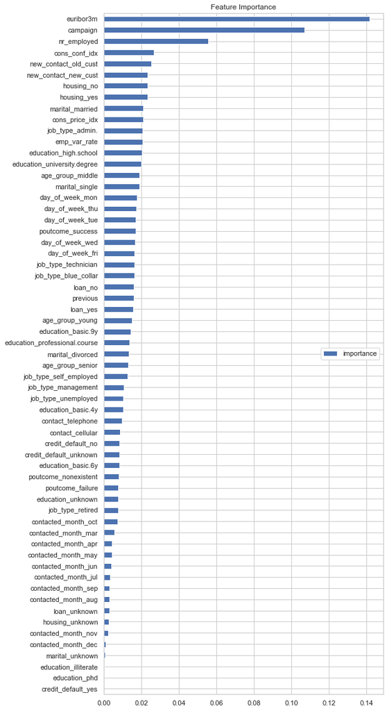

```python
feat_imp.sort_values('importance').plot(kind='barh',title='Feature Importance',figsize=(8,20)).legend(loc='right')
```

```python
feat_zip=feat_imp[feat_imp['importance']>0.015].index
```

```python
feat_zip=feat_zip.to_list()
```

```python
print(feat_zip)
```

[output not shown]

```python
## Transformed Train and Test sets
```

```python
#Train Dataset
X_train=X_train[feat_zip]
```

```python
print(X_train.shape)
```

```
(30891, 27)
```

```python
X_test=X_test[feat_zip]
```

```python
print(X_test.shape)
```

```
(10297, 27)
```

```python
X_train.head(2)
```

|  | campaign | previous | emp_var_rate | cons_price_idx | cons_conf_idx | euribor3m | nr_employed | job_type_admin. | job_type_blue_collar | job_type_technician | marital_married | marital_single | education_high.school | education_university.degree | housing_no | housing_yes | loan_no | loan_yes | poutcome_success | age_group_middle | day_of_week_fri | day_of_week_mon | day_of_week_thu | day_of_week_tue | day_of_week_wed | new_contact_new_cust | new_contact_old_cust |
| --- | --- | --- | --- | --- | --- | --- | --- | --- | --- | --- | --- | --- | --- | --- | --- | --- | --- | --- | --- | --- | --- | --- | --- | --- | --- | --- | --- |
| 549 | 1 | 0 | 1.1 | 93.994 | -36.4 | 4.857 | 5191.0 | 0 | 1 | 0 | 1 | 0 | 0 | 0 | 0 | 0 | 0 | 0 | 0 | 1 | 0 | 0 | 0 | 1 | 0 | 1 | 0 |
| 1974 | 4 | 0 | 1.1 | 93.994 | -36.4 | 4.855 | 5191.0 | 0 | 1 | 0 | 0 | 1 | 1 | 0 | 1 | 0 | 1 | 0 | 0 | 0 | 1 | 0 | 0 | 0 | 0 | 1 | 0 |

# Model Building and Evaluation

Since, this is a imbalance dataset with 8:1 imbalance, accuracy is not a good metric to evaluate performance.

**Balanced Accuracy and F1 scores are better metrics.**

Balanced accuracy=(TPR+TNR)/2 where TPR and TNR are true positive and true negative rates.

It gives a measure of how well the model is capturing both the classes and unlike accuracy is not skewed by the majority class.

```python
from sklearn.metrics import accuracy_score, balanced_accuracy_score,classification_report, recall_score, precision_score, confusion_matrix, f1_score
```

```python
def accuracy_BalancedAccuracy(model,X_train,X_test,y_train,y_test):
    print(model)
    model.fit(X_train,y_train)

    y_pred=model.predict(X_test)

    accuracy=accuracy_score(y_test,y_pred)
    bal_accuracy=balanced_accuracy_score(y_test,y_pred)

    print('Accuracy: {}'.format(accuracy))
    print('Balanced Accuracy: {}'.format(bal_accuracy))

    return accuracy,bal_accuracy
```

```python
# creating a model dictionary
model_dict={'Random Forest':RandomForestClassifier(n_estimators=50,max_depth=5,n_jobs=-1,random_state=50),
           'Logit': LogisticRegression(random_state=50),
           'AdaBoost':AdaBoostClassifier(n_estimators=50,random_state=50),
           'balanced RF':BalancedRandomForestClassifier(n_estimators=50, max_depth=5,n_jobs=-1,
                                                        random_state=50,sampling_strategy='auto'),
           'balanced_logit':BalancedBaggingClassifier(base_estimator=LogisticRegression(),n_estimators=50,
                                                       n_jobs=-1,random_state=50),
           'Undersampled Boost':RUSBoostClassifier(base_estimator=None, #None means Decision Stump
                                                   n_estimators=50,sampling_strategy='auto', random_state=50),
           'EasyEnsemble':EasyEnsembleClassifier(n_estimators=100, warm_start=False, sampling_strategy='auto',
                                                 n_jobs=-1, random_state=50),
            'XGBoost': XGBClassifier(n_estimators=50, random_state=50, n_jobs=-1, scale_pos_weight=8.5)}
```

```python
accuracy_dict={}
balanced_accuracy_dict={}

for model in model_dict.keys():
    accuracy,balanced_accuracy=accuracy_BalancedAccuracy(model_dict[model],X_train,X_test,y_train,y_test)

    accuracy_dict[model]=accuracy
    balanced_accuracy_dict[model]=balanced_accuracy

    print()
```

```
RandomForestClassifier(max_depth=5, n_estimators=50, n_jobs=-1, random_state=50)
Accuracy: 0.899970865300573
Balanced Accuracy: 0.5935100073678995

LogisticRegression(random_state=50)
Accuracy: 0.8993881713120326
Balanced Accuracy: 0.5780230962023069

AdaBoostClassifier(random_state=50)
Accuracy: 0.9004564436243566
Balanced Accuracy: 0.5994679708835181

BalancedRandomForestClassifier(max_depth=5, n_estimators=50, n_jobs=-1,
                               random_state=50)
Accuracy: 0.8043119355151986
Balanced Accuracy: 0.7321666575611266

BalancedBaggingClassifier(base_estimator=LogisticRegression(), n_estimators=50,
                          n_jobs=-1, random_state=50)
Accuracy: 0.7474992716325143
Balanced Accuracy: 0.7191270025548628

RUSBoostClassifier(random_state=50)
Accuracy: 0.8338350976012431
Balanced Accuracy: 0.7343886938785731

EasyEnsembleClassifier(n_estimators=100, n_jobs=-1, random_state=50)
Accuracy: 0.832475478294649
Balanced Accuracy: 0.7332441938903345

XGBClassifier(base_score=None, booster=None, callbacks=None,
              colsample_bylevel=None, colsample_bynode=None,
              colsample_bytree=None, early_stopping_rounds=None,
              enable_categorical=False, eval_metric=None, gamma=None,
              gpu_id=None, grow_policy=None, importance_type=None,
              interaction_constraints=None, learning_rate=None, max_bin=None,
              max_cat_to_onehot=None, max_delta_step=None, max_depth=None,
              max_leaves=None, min_child_weight=None, missing=nan,
              monotone_constraints=None, n_estimators=50, n_jobs=-1,
              num_parallel_tree=None, predictor=None, random_state=50,
              reg_alpha=None, reg_lambda=None, ...)
Accuracy: 0.8301447023404875
Balanced Accuracy: 0.7319318579323291
```

```python
accuracy_dict
```

```
{'Random Forest': 0.899970865300573,
 'Logit': 0.8993881713120326,
 'AdaBoost': 0.9004564436243566,
 'balanced RF': 0.8043119355151986,
 'balanced_logit': 0.7474992716325143,
 'Undersampled Boost': 0.8338350976012431,
 'EasyEnsemble': 0.832475478294649,
 'XGBoost': 0.8301447023404875}
```

```python
balanced_accuracy_dict
```

```
{'Random Forest': 0.5935100073678995,
 'Logit': 0.5780230962023069,
 'AdaBoost': 0.5994679708835181,
 'balanced RF': 0.7321666575611266,
 'balanced_logit': 0.7191270025548628,
 'Undersampled Boost': 0.7343886938785731,
 'EasyEnsemble': 0.7332441938903345,
 'XGBoost': 0.7319318579323291}
```

```python
for model in model_dict.values():
    print(model)
    model.fit(X_train,y_train)
    y_train_pred=model.predict(X_train)
    y_test_pred=model.predict(X_test)
    print(classification_report(y_train, y_train_pred, digits=4))
```

[output not shown]

[output cut: 68 more lines]

[output not shown]

```python
accuracy_ser=pd.Series(accuracy_dict)
balanced_accuracy_ser=pd.Series(balanced_accuracy_dict)
```

```python
results_df=pd.concat([accuracy_ser,balanced_accuracy_ser],axis=1)
```

```python
results_df.rename(columns={0:'Accuracy',1:'Balanced_accuracy'},inplace=True)
```

```python
results_df
```

|  | Accuracy | Balanced_accuracy |
| --- | --- | --- |
| Random Forest | 0.899971 | 0.593510 |
| Logit | 0.899388 | 0.578023 |
| AdaBoost | 0.900456 | 0.599468 |
| balanced RF | 0.804312 | 0.732167 |
| balanced_logit | 0.747499 | 0.719127 |
| Undersampled Boost | 0.833835 | 0.734389 |
| EasyEnsemble | 0.832475 | 0.733244 |
| XGBoost | 0.830145 | 0.731932 |

```python
results_df.index
```

```
Index(['Random Forest', 'Logit', 'AdaBoost', 'balanced RF', 'balanced_logit',
       'Undersampled Boost', 'EasyEnsemble', 'XGBoost'],
      dtype='object')
```

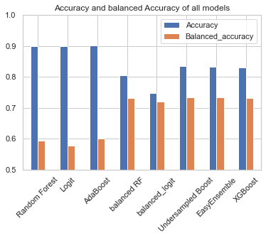

```python
results_df.plot.bar(figsize=(6,4))
plt.ylim([0.5,1])
plt.title('Accuracy and balanced Accuracy of all models')
plt.xticks(rotation=45)
plt.show()
```

So, we see that Accuracy is better for the models: Logistic Regression, Random Forest and AdaBoost,  
which is misleading for imbalanced classification evaluation.

Following are the imbalanced ensemble approaches:

- Balanced Random Forest (where each Decision Tree comprises of minority and bootstrapped majority).
- Balanced Bagging with Logistic Regression as estimator.
- Random Undersampled Boost(comprising of Decision stumps like AdaBoost but with random undersampling in each step).
- XGBoost with scale_pos_weight parameter that handles the class imbalance.

Ensemble approaches will be better suited for our business problem because even though their overall accuracy is lower,  
they do a better job at identifying the true positives (minority) as well as true negatives (majority) .

# Improving the XGBoost Classifier Model

```python
from xgboost import XGBClassifier
model1 = XGBClassifier(n_estimators=50, random_state=50, n_jobs=-1, scale_pos_weight=8.5)
model1.fit(X_train, y_train)
```

```
XGBClassifier(base_score=0.5, booster='gbtree', callbacks=None,
              colsample_bylevel=1, colsample_bynode=1, colsample_bytree=1,
              early_stopping_rounds=None, enable_categorical=False,
              eval_metric=None, gamma=0, gpu_id=-1, grow_policy='depthwise',
              importance_type=None, interaction_constraints='',
              learning_rate=0.300000012, max_bin=256, max_cat_to_onehot=4,
              max_delta_step=0, max_depth=6, max_leaves=0, min_child_weight=1,
              missing=nan, monotone_constraints='()', n_estimators=50,
              n_jobs=-1, num_parallel_tree=1, predictor='auto', random_state=50,
              reg_alpha=0, reg_lambda=1, ...)
```

```python
pred = model1.predict(X_test)
```

```python
print(classification_report(y_test, pred))
```

```
              precision    recall  f1-score   support

           0       0.95      0.86      0.90      9144
           1       0.35      0.61      0.44      1153

    accuracy                           0.83     10297
   macro avg       0.65      0.73      0.67     10297
weighted avg       0.88      0.83      0.85     10297
```

```python
lr_probs = model1.predict_proba(X_test)[:,1]
```

```python
lr_probs
```

```
array([0.05607569, 0.29963934, 0.25663462, ..., 0.16165741, 0.2875796 ,
       0.22552325], dtype=float32)
```

```
Best Threshold=0.695308, F-Score=0.477
```

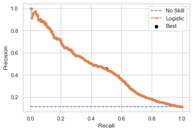

```python
#from sklearn.metrics import roc_curve
from sklearn.metrics import precision_recall_curve
precision, recall, thresholds = precision_recall_curve(y_test, lr_probs)
# convert to f score
fscore = (2 * precision * recall) / (precision + recall)
# locate the index of the largest f score
ix = np.argmax(fscore)
print('Best Threshold=%f, F-Score=%.3f' % (thresholds[ix], fscore[ix]))
# plot the roc curve for the model
no_skill = len(y_test[y_test==1]) / len(y_test)
plt.plot([0,1], [no_skill,no_skill], linestyle='--', label='No Skill')
plt.plot(recall, precision, marker='.', label='Logistic')
plt.scatter(recall[ix], precision[ix], marker='o', color='black', label='Best')
# axis labels
plt.xlabel('Recall')
plt.ylabel('Precision')
plt.legend()
# show the plot
plt.show()
```

```python
pred = [0 if x < 0.695308 else 1 for x in lr_probs]
print(classification_report(y_test, pred))
```

```
              precision    recall  f1-score   support

           0       0.94      0.92      0.93      9144
           1       0.45      0.50      0.48      1153

    accuracy                           0.88     10297
   macro avg       0.69      0.71      0.70     10297
weighted avg       0.88      0.88      0.88     10297
```

```python
from sklearn import metrics
```

```
TEST DATA ACCURACY 0.8764688744294454

Test data f1-score for class 0 0.9299790818011671

Test data f1-score for class 1 0.4761120263591433
```

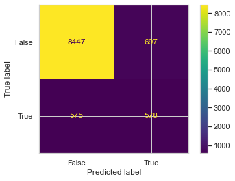

```python
### Test data accuracy
print("\nTEST DATA ACCURACY",accuracy_score(y_test,pred))
print("\nTest data f1-score for class 0",f1_score(y_test,pred,pos_label=0))
print("\nTest data f1-score for class 1",f1_score(y_test,pred,pos_label=1))

#confusion matrix
actual1 = y_test
predicted1 = pred

confusion_matrix1 = metrics.confusion_matrix(actual1, predicted1)

cm_display1 = metrics.ConfusionMatrixDisplay(confusion_matrix = confusion_matrix1, display_labels = [False, True])

cm_display1.plot()
plt.show()
```

# Proof of Concept